# MUSA 508 Assignment 1

Indicators for Transit-Oriented Development Analysis for Minneapolis-St. Paul, MN-WI Urbanized Area and Metro Transit Light Rail

Benjamin She

9/23/2021

```r
library(tidyverse)
library(tidycensus)
library(tidytransit)
library(tigris)
library(sf)
library(kableExtra)
library(gt)

source("https://raw.githubusercontent.com/urbanSpatial/Public-Policy-Analytics-Landing/master/functions.r")
```

# Introduction

The Minneapolis-St. Paul metropolitan area (or Twin Cities) is one of the fastest-growing regions in the United States. Its metropolitan region growth of 10.26% from 2020 to 2010 puts it at the 16th largest metropolitan statistical area. In addition, its transit agency, Metro Transit, has been growing its transit network at a significant pace. Following the 2004 opening of the initial Blue Line from downtown Minneapolis to the international airport and the Mall of America, the agency followed up with the opening of the Green Line in 2014, connecting the Twin Cities by rail transit for the first time since 1953, when this “Central Corridor Interurban”, the last line in the Twin Cities streetcar network, was replaced with buses. Additional construction of bus rapid transit lines and arterial transit constitute one of the largest such rollouts of a frequent, high-quality bus grids anywhere in the United States.

What this analysis is focused on, however, is the effects of the light rail lines’ recent openings on transit-oriented development (TOD), particularly regarding the Green Line. Currently, the Blue Line averaged 32,000 riders and the Green Line 44,000 riders per day pre-pandemic. With this ridership outpacing any other bus route, it is of interest to understand if the lines’ popularity has resulted in outsized demand to live next to light rail compared to anywhere else in the Twin Cities region. For some, this is also an issue of equity and justice. In the case of the Green Line, which is one of the strongest-anchored transit corridors in the US, there was significant concern and opposition regarding potential gentrification and displacement effects that would be felt by Southeast Asian communities along the line. Nonetheless, the line like the Blue Line connects numerous employment centers such as the University of Minnesota, the State Capitol, and both downtowns of Minneapolis and St. Paul, and would be a throughly obvious development corridor.

The primary dataset selected was the American Community Survey 5-year Estimates for 2005-2009 and 2015-2019. Decennial Census figures would have been preferred for a broader 20-year comparison, but detailed 2020 data was not readily available yet, and the 2000 Census did not contain statistics for commute type. Ultimately, six indicators were sourced and visualized to get insight into TOD effects in time and space.

# Wrangling data

## First get boundary of Minneapolis-St Paul urbanized area

The urbanized area was selected, as the light rail lines not only serve four jurisdictions (the Twin Cities, Richfield, and Bloomington), but can be said to serve and function in a regional context. This uses the `tigris` package and filters for UA code `57628`

```r
twincities <- urban_areas(cb = TRUE) %>%
  filter(UACE10  ==  "57628") %>%
  select(geometry)
```

## Then get ACS tract data for whole state and intersect by boundary to get UA tracts

Instead of merely displaying population, normalizing population by tract area (in square miles) will accurately visualize choropleth data.

```r
getACSyr <- function(yearACS) {
  temp <- get_acs(geography = 'tract',
                year = yearACS,
                variables = c("B25026_001","B25058_001","B08301_001","B08301_010"),
                state = "MN",
                geometry = TRUE,
                output = "wide") %>%
    mutate(year = yearACS) %>%
    mutate(TotalPop = B25026_001E) %>%
    # normalize population as expected of choropleths; use square miles
    mutate(PopDens = B25026_001E / as.numeric(st_area(geometry) / 2.59e+6)) %>%
    mutate(MedRent = B25058_001E) %>%
    mutate(PctTransit = B08301_010E / B08301_001E * 100) %>%
    select(!(B25026_001E:B08301_010M))

  st_join(temp, twincities, join = st_within, left = FALSE) %>%
    st_transform('EPSG:2812')
}

tracts09 <- getACSyr(2009)
tracts19 <- getACSyr(2019)
```

## Wrangle in LEHD WAC

Here we wrangle in LEHD Workforce Area Characteristics, which has job counts by block group. Then summarize by tract.

```r
lehdwac08 <- read_csv("data/mn_wac_S000_JT00_2008.csv") %>%
  select(w_geocode,C000) %>%
  mutate(GEOID = str_sub(w_geocode,1,11)) %>%
  group_by(GEOID) %>%
  summarise(jobs = sum(C000))
lehdwac18 <- read_csv("data/mn_wac_S000_JT00_2018.csv") %>%
  select(w_geocode,C000) %>%
  mutate(GEOID = str_sub(w_geocode,1,11)) %>%
  group_by(GEOID) %>%
  summarise(jobs = sum(C000))
```

Like population, the choropleth should normalize jobs by square mile area.

```r
tracts09 <- tracts09 %>% left_join(lehdwac08,by = "GEOID") %>%
  mutate(JobDens = jobs / as.numeric(st_area(geometry) / 2.59e+6))
tracts19 <- tracts19 %>% left_join(lehdwac18,by = "GEOID") %>%
  mutate(JobDens = jobs / as.numeric(st_area(geometry) / 2.59e+6))

allTracts <- rbind(tracts09,tracts19)
```

## Wrangle rail stops and centroid buffers

The Twin Cities’ transit agency is Metro Transit, which operates two light rail lines: the Blue Line and Green Line. The GTFS package here is a snapshot taken from the [Transitland](https://transit.land) GTFS repository, with the Blue and Green Lines designated as route 901 and 902.

Four buffers were created from station point data: one half-mile buffer for each station, a unionized shapefile of the 1/2 mile buffers, a quarter-mile buffer for finer analysis, and a 1-foot buffer to utilize in the `multipleRingBuffer()` function.

```r
metrotransit <- read_gtfs("data/gtfs.zip")

service_id <- filter(metrotransit$calendar, monday == 1) %>% pull(service_id)
route_id <- filter(metrotransit$routes, route_id == c('901','902')) %>% pull(route_id)
railStops <- filter_stops(metrotransit,service_id,route_id) %>%
  group_by(stop_name) %>% slice(1) %>% stops_as_sf(2812)
railLines <- get_route_geometry(gtfs_as_sf(metrotransit), route_id, service_id)

# include one-foot buffer for multipleRingBuffer
railBuffers <- bind_rows(
  st_buffer(railStops,2640) %>%
    mutate(Legend = "Buffer") %>%
    dplyr::select(stop_name,Legend),
  st_union(st_buffer(railStops,2640)) %>%
    st_sf() %>%
    mutate(Legend = "Unionized Buffer"),
  st_union(st_buffer(railStops,1320)) %>%
    st_sf() %>%
    mutate(Legend = "Quarter-mile Buffer"),
  st_union(st_buffer(railStops,1)) %>%
    st_sf() %>%
    mutate(Legend = "1-foot Buffer")
)

buffer <- filter(railBuffers, Legend == "Unionized Buffer")
quarter <- filter(railBuffers,Legend == "Quarter-mile Buffer")
onefoot <- filter(railBuffers, Legend == "1-foot Buffer")
```

## Select for TOD tracts by buffer using centroid method

First get the geometric centroids of all the tracts, then choose those that intersect with the 1/2 mile buffer. Median rent was also adjusted at this step for inflation.

```r
allTracts.group <-
  rbind(
    st_centroid(allTracts)[buffer,] %>%
      st_drop_geometry() %>%
      left_join(allTracts) %>%
      st_sf() %>%
      mutate(TOD = "TOD"),
    st_centroid(allTracts)[buffer, op = st_disjoint] %>%
      st_drop_geometry() %>%
      left_join(allTracts) %>%
      st_sf() %>%
      mutate(TOD = "Non-TOD")) %>%
  mutate(MedRent = ifelse(year  ==  2009, MedRent * 1.275, MedRent))
```

# Outputs of TOD indicators

Four indicators were included in the initial time-space analysis: population density, employment density by workplace, median rent, and percent of commuters that took transit to work, or its mode share.

Population density and employment density were summarized on the tract level and divided by the geometric area of each tract in square miles. Transit mode share was calculated by dividing the number of estimated transit riders by estimated total commuters, all in the ACS 5-year estimates.

Employment data was found in the Census Bureau’s Longitudinal Employer-Household Dynamics datasets, for workplace area characteristics.

```r
palette5 <- c("#f0f9e8","#bae4bc","#7bccc4","#43a2ca","#0868ac")
```

## Define TOD and non-TOD tracts

Here we show what tracts in the urbanized area are considered as classified as a TOD-containing tract. The extent of the Blue and Green Lines are shown as well. Both lines originate in downtown Minneapolis; the Blue Line goes south to the airport, while the Green Line travels in an east-west corridor to St. Paul.

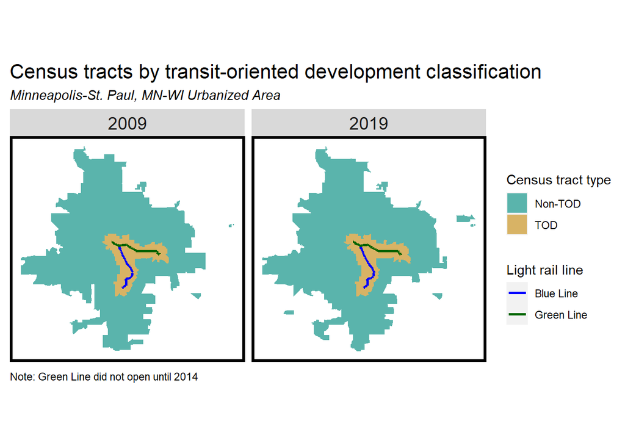

```r
ggplot() +
  geom_sf(data = allTracts.group, aes(fill = TOD), color = "transparent") +
  geom_sf(data = railLines, aes(color = route_id),size = 1) +
  facet_wrap(~year) +
  scale_fill_manual(name = "Census tract type",
                    values = c("#5ab4ac", "#d8b365")) +
  scale_color_manual(name = "Light rail line",
                     values = c('blue', 'darkgreen'),
                     labels = c('Blue Line', 'Green Line')) +
  mapTheme() +
  labs(title = "Census tracts by transit-oriented development classification",
       subtitle = "Minneapolis-St. Paul, MN-WI Urbanized Area",
       caption = "Note: Green Line did not open until 2014")
```

## Step 2: Time-space indicator maps

```r
plotStep2 <- function(indicator, indTitle, units) {
  ggplot() +
    geom_sf(data = allTracts.group, aes(fill = q5(eval(parse(text = indicator)))), color = "transparent") +
    geom_sf(data = buffer, color = "red", fill = "transparent") +
    scale_fill_manual(values = palette5,
                      labels = qBr(allTracts.group, indicator),
                      name = paste0(indTitle,"\n",units,"\n(Quintile breaks)")) +
    labs(title = paste0(indTitle,", 2009-2019"),
         subtitle = "Minneapolis-St. Paul, MN-WI Urbanized Area",
         caption = "Red border = 1/2 mile buffer around light rail stations") +
    mapTheme() +
    facet_wrap(~year)
}
```

### Population density map

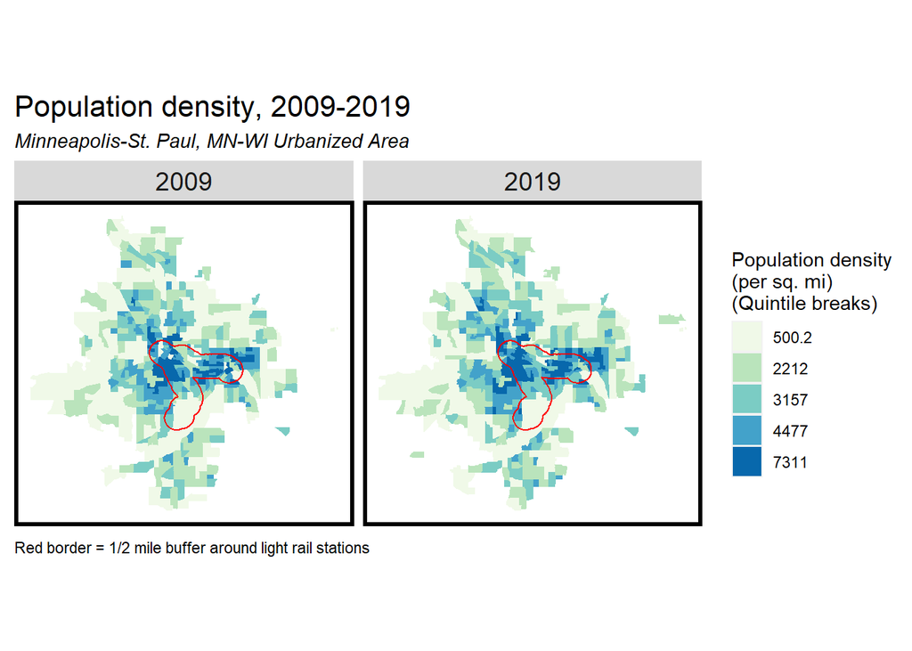

```r
plotStep2("PopDens","Population density","(per sq. mi)")
```

### Employment density map

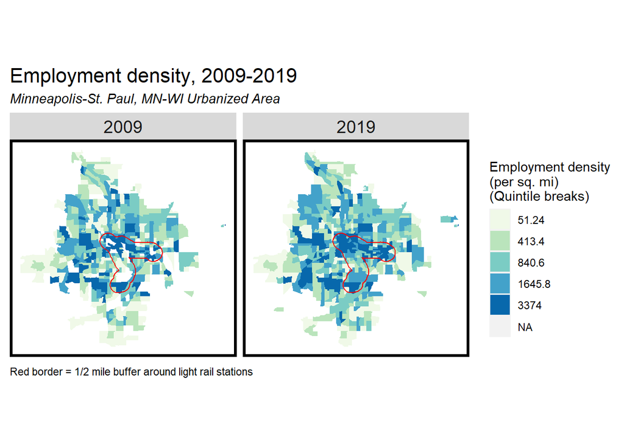

```r
plotStep2("JobDens","Employment density","(per sq. mi)")
```

### Median rent map

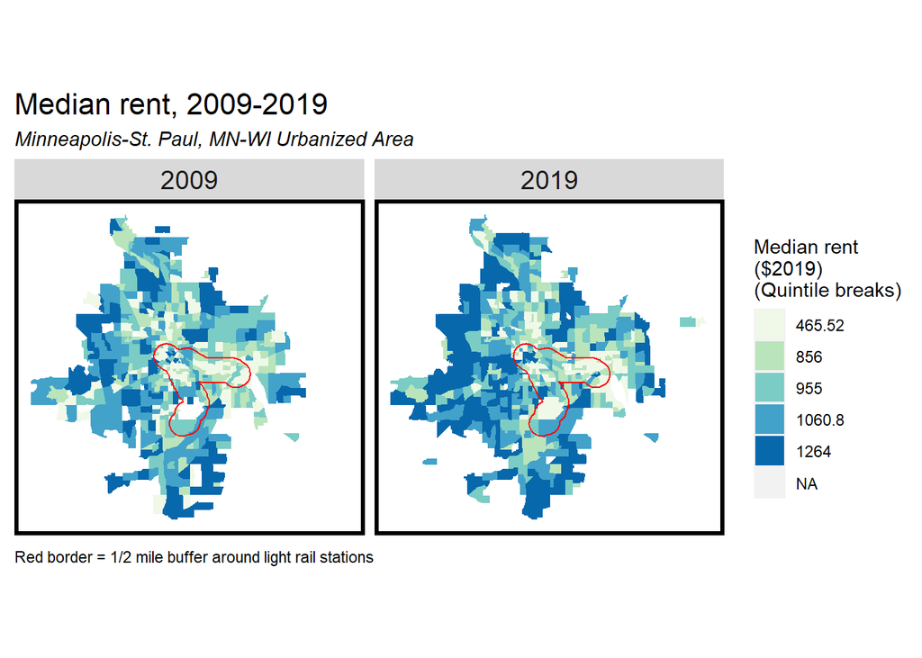

```r
plotStep2("MedRent", "Median rent","($2019)")
```

### Percent transit share map

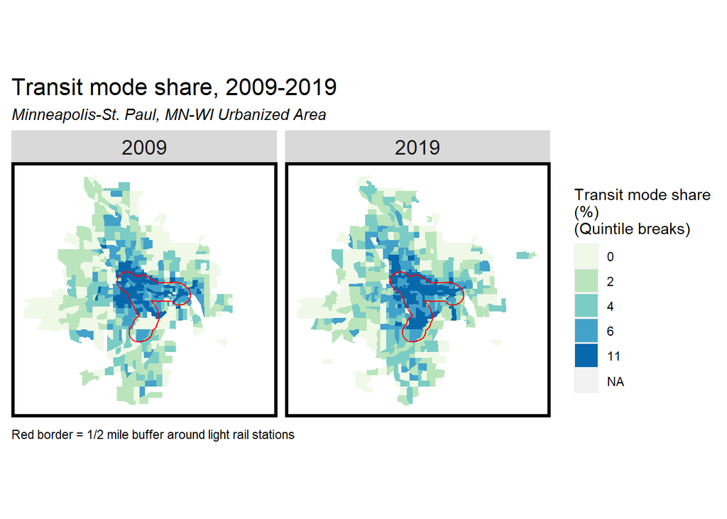

```r
plotStep2("PctTransit", "Transit mode share","(%)")
```

## Step 3 & 4: Grouped bar plot and table

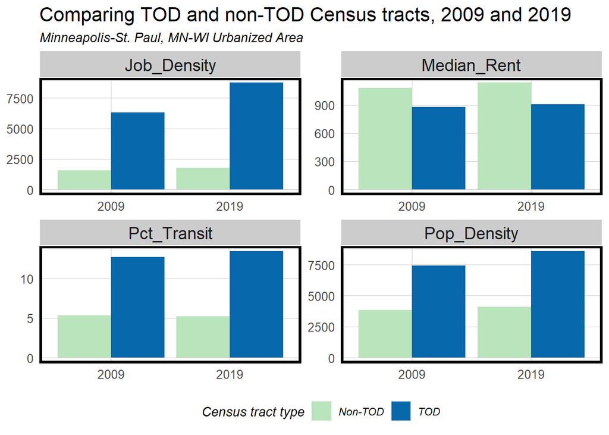

```r
allTracts.Summary <-
  st_drop_geometry(allTracts.group) %>%
  group_by(year, TOD) %>%
  summarize(Pop_Density = mean(PopDens, na.rm = T),
            Job_Density = mean(JobDens, na.rm = T),
            Median_Rent = mean(MedRent, na.rm = T),
            Pct_Transit = mean(PctTransit, na.rm = T)) %>%
  gather(Variable, Value, -year, -TOD)

ggplot(allTracts.Summary, aes(factor(year), Value, fill = TOD)) +
  geom_bar(stat = "identity", position = "dodge") +
  scale_fill_manual(name = "Census tract type", values = c("#bae4bc", "#0868ac")) +
  facet_wrap(~Variable, scales = "free", ncol = 2) +
  labs(title = "Comparing TOD and non-TOD Census tracts, 2009 and 2019",
       subtitle = "Minneapolis-St. Paul, MN-WI Urbanized Area") +
  plotTheme() + theme(legend.position = "bottom",
                      axis.title = element_blank())
```

```r
# table using kable
allTracts.Summary %>%
  unite(year.TOD, year, TOD, sep = ": ", remove = T) %>%
  mutate(Value = round(Value, 2)) %>%
  spread(year.TOD, Value) %>%
  kable(caption = "Comparing TOD and non-TOD Census tracts, 2009 and 2019") %>%
  kable_material("striped", full_width = F, html_font = "Helvetica") %>%
  footnote(footnote_as_chunk = T,
           general_title = "",
           general = "Minneapolis-St. Paul, MN-WI Urbanized Area")
```

Comparing TOD and non-TOD Census tracts, 2009 and 2019

| Variable | 2009: Non-TOD | 2009: TOD | 2019: Non-TOD | 2019: TOD |
| --- | --- | --- | --- | --- |
| Job_Density | 1579.25 | 6328.69 | 1783.66 | 8755.36 |
| Median_Rent | 1081.90 | 880.73 | 1137.46 | 906.10 |
| Pct_Transit | 5.34 | 12.67 | 5.21 | 13.44 |
| Pop_Density | 3858.35 | 7423.12 | 4098.45 | 8603.00 |

Minneapolis-St. Paul, MN-WI Urbanized Area

```r
# table using gt
allTracts.Summary %>%
  unite(year.TOD, year, TOD, sep = ": ", remove = T) %>%
  mutate(Value = round(Value, 2)) %>%
  spread(year.TOD, Value) %>%
  gt(rowname_col = "Variable") %>%
  tab_spanner_delim(delim = ':') %>%
  tab_header(title = "Comparing TOD and non-TOD Census tracts, 2009 and 2019",
             subtitle = "Minneapolis-St. Paul, MN-WI Urbanized Area") %>%
  opt_align_table_header(align = "left") %>%
  tab_style(style = list(cell_text(align = "right")),
            locations = cells_stub(rows = TRUE)) %>%
  tab_options(table.font.names = 'Helvetica',
              stub.font.weight = 'bold')
```

Comparing TOD and non-TOD Census tracts, 2009 and 2019

Minneapolis-St. Paul, MN-WI Urbanized Area

|  | 2009 Non-TOD | 2009 TOD | 2019 Non-TOD | 2019 TOD |
| --- | --- | --- | --- | --- |
| Job_Density | 1579.25 | 6328.69 | 1783.66 | 8755.36 |
| Median_Rent | 1081.90 | 880.73 | 1137.46 | 906.10 |
| Pct_Transit | 5.34 | 12.67 | 5.21 | 13.44 |
| Pop_Density | 3858.35 | 7423.12 | 4098.45 | 8603.00 |

## Step 5: graduated symbol maps

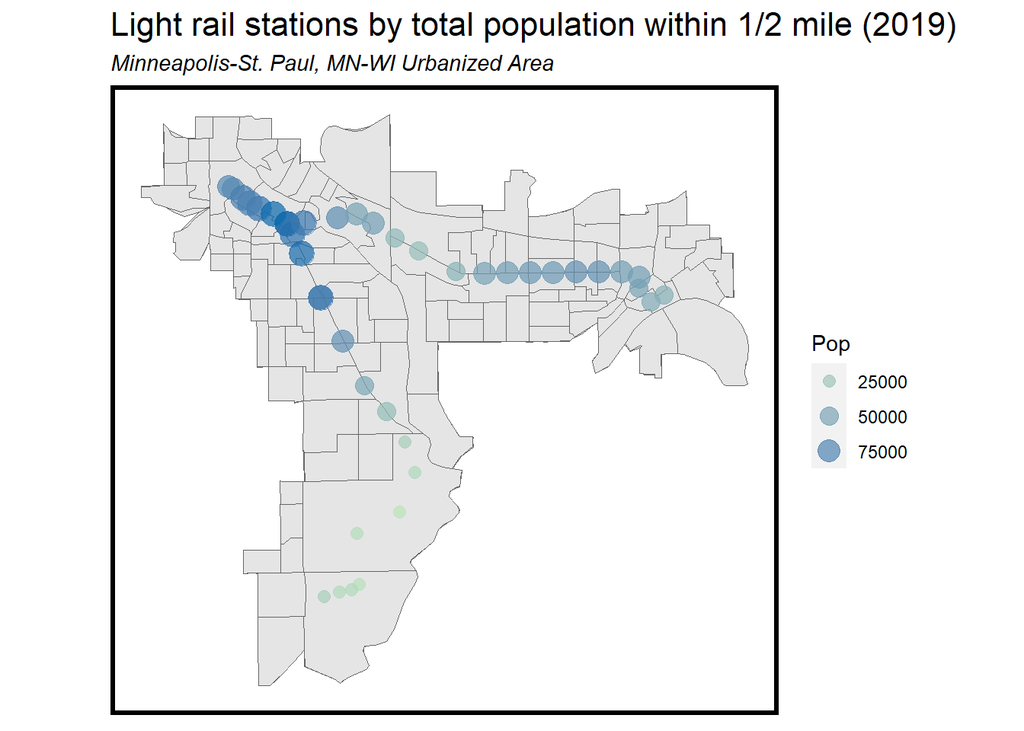

```r
stationStat <- st_join(filter(railBuffers,Legend == "Buffer"),
                       st_centroid(filter(allTracts,year == 2019))) %>%
  st_drop_geometry() %>%
  group_by(stop_name) %>%
  summarise(Pop = sum(TotalPop, na.rm = T), Rent = median(MedRent, na.rm = T)) %>%
  full_join(select(railStops,stop_name,geometry),by = "stop_name")

ggplot() +
  geom_sf(data = filter(allTracts.group,TOD == "TOD"), color = "#666666", lwd = .1) +
  geom_sf(data = stationStat, aes(geometry = geometry, size = Pop, color = Pop), alpha = 0.7) +
  scale_size_binned() + scale_color_gradient(low = "#bae4bc",high = "#0868ac") +
  guides(size = guide_legend(), color = guide_legend()) + mapTheme() +
  labs(title = "Light rail stations by total population within 1/2 mile (2019)",
       subtitle = "Minneapolis-St. Paul, MN-WI Urbanized Area")
```

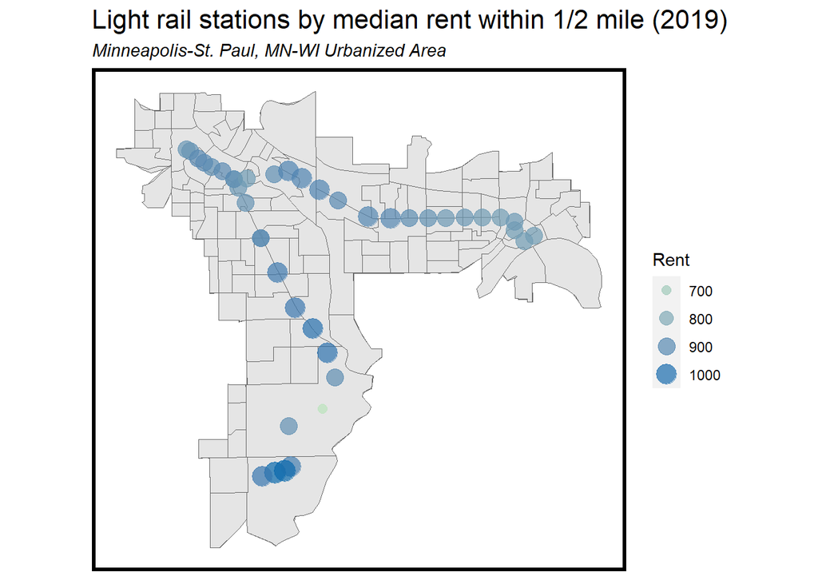

```r
ggplot() +
  geom_sf(data = filter(allTracts.group,TOD == "TOD"), color = "#666666", lwd = .1) +
  geom_sf(data = stationStat, aes(geometry = geometry, size = Rent, color = Rent), alpha = 0.7) +
  scale_size_binned() + scale_color_gradient(low = "#bae4bc",high = "#0868ac") +
  guides(size = guide_legend(), color = guide_legend()) + mapTheme() +
  labs(title = "Light rail stations by median rent within 1/2 mile (2019)",
       subtitle = "Minneapolis-St. Paul, MN-WI Urbanized Area")
```

## Step 6: geom_line & multiple ring buffer

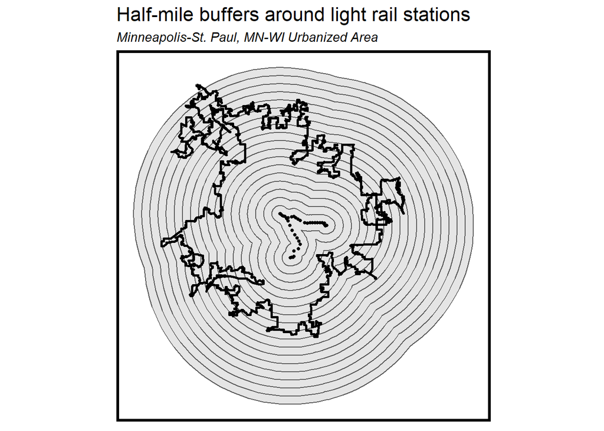

```r
ggplot() +
  geom_sf(data = multipleRingBuffer(onefoot, 50000, 2640)) +
  geom_sf(data = twincities,fill = "transparent",color = "black",size = 1) +
  geom_sf(data = railStops,size = 1) +
  mapTheme() +
  labs(title = "Half-mile buffers around light rail stations",
       subtitle = "Minneapolis-St. Paul, MN-WI Urbanized Area")
```

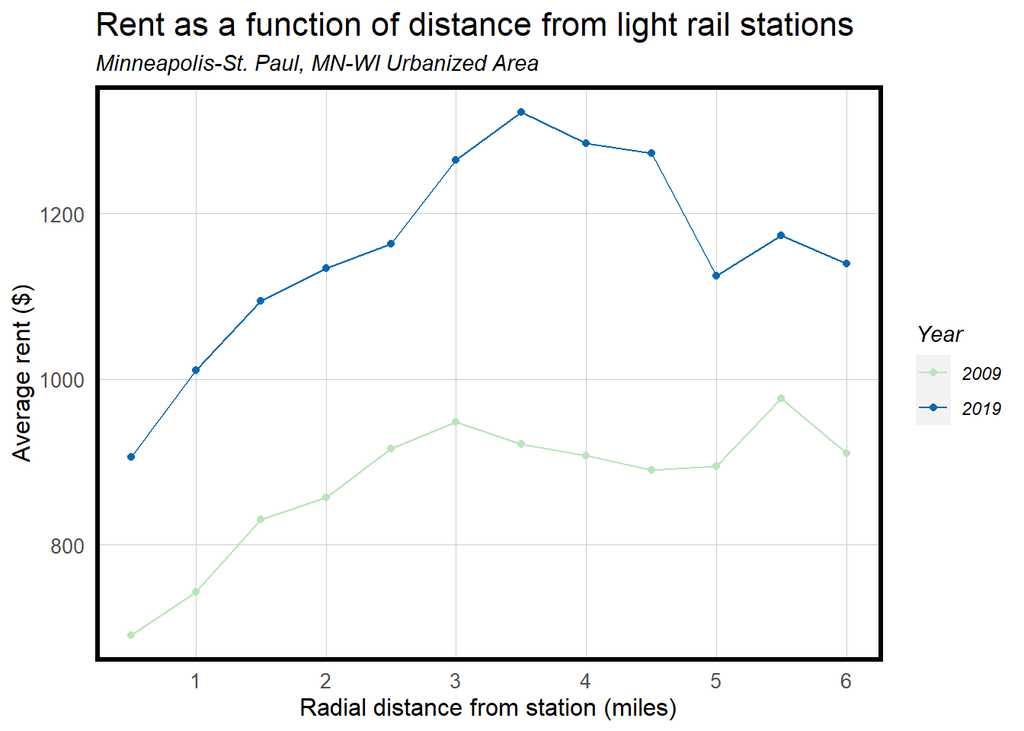

```r
allTracts.rings <-
  st_join(st_centroid(dplyr::select(allTracts, GEOID, year)),
          multipleRingBuffer(onefoot, 50000, 2640)) %>%
  st_drop_geometry() %>%
  left_join(select(allTracts, GEOID, MedRent, year),
            by = c("GEOID" = "GEOID", "year" = "year")) %>%
  st_sf() %>%
  mutate(distance = distance / 5280) %>%
  st_drop_geometry() %>%
  group_by(year, distance) %>%
  summarise(RingRent = mean(MedRent, na.rm = T)) %>%
  arrange(year, distance)

ggplot(allTracts.rings, aes(x = distance,y = RingRent,color = factor(year))) +
  geom_line() +
  geom_point() +
  scale_color_manual(name = "Year",values = c("#bae4bc", "#0868ac")) +
  scale_x_continuous(breaks = seq(0,6,by = 1)) +
  plotTheme() +
  labs(title = "Rent as a function of distance from light rail stations",
       subtitle = "Minneapolis-St. Paul, MN-WI Urbanized Area",
       x = "Radial distance from station (miles)",
       y = "Average rent ($)")
```

## Step 7: 311 data for Minneapolis

311 data was only available for Minneapolis. Crime data exists for St. Paul but was not geocoded, and only had block addresses; geocoding would take too long.

The plot shows a higher 311 requests density in the central region of Minneapolis, approximately the junction of two rail lines. However, we can hardly draw a conclusion of any relationship between TOD and the density of 311 requests from the given data.

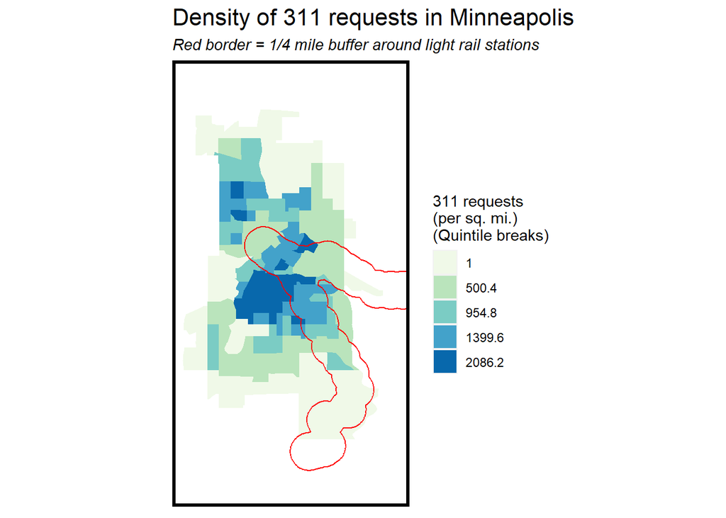

```r
data311 <- read_csv("data/Public_311_2019.csv") %>%
  st_as_sf(coords = c('Lon', 'Lat'), crs = 4326) %>%
  st_transform(st_crs(allTracts))

choro311 <- st_join(filter(allTracts,year == 2019), data311, join = st_intersects, left = F) %>%
  group_by(GEOID) %>%
  summarise(tot311 = n()) %>%
  mutate(dens311 = tot311 / as.numeric(st_area(geometry) / 2.59e+6))

ggplot() +
  geom_sf(data = choro311, aes(fill = q5(dens311)), color = "transparent") +
  geom_sf(data = quarter, color = "red", fill = "transparent") +
  coord_sf(crs = st_crs(4326),xlim = c(-93.36,-93.15),ylim = c(44.82,45.1), expand = FALSE) +
  scale_fill_manual(values = palette5,
                  labels = qBr(choro311, "dens311"),
                  name = paste0("311 requests\n(per sq. mi.)\n(Quintile breaks)")) +
  mapTheme() +
  labs(title = "Density of 311 requests in Minneapolis",
       subtitle = "Red border = 1/4 mile buffer around light rail stations")
```